# Insertions and deletions in the great tit genome

PopGroup 50 - 06/01/17

## Introduction

## Insertions and deletions

- short INDELs: sections of DNA < 50bp that are deleted or inserted in a genome

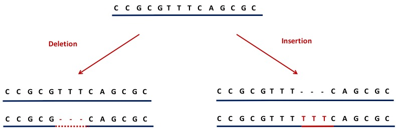

## INDELs often overlooked

- Disproportionately occur in repetitive sequence
- Hard to align
- 1/8 as frequent as SNPs in humans

(Earl et al., 2014; Montgomery et al., 2013)

## The importance of INDELs in genome evolution

- Influence genome size:
  - low deletion rate \(\rightarrow\) large genomes?
  - high deletion rate \(\rightarrow\) compact genomes?
- Insertions may be favoured:
  - biased gene conversion
  - minimum intron size
  - polarisation error

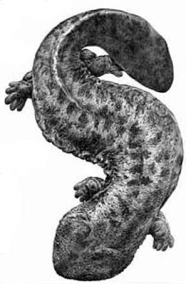

(Leushkin and Bazykin, 2013; Nam and Ellegren, 2012; Ometto et al., 2005; Sun et al., 2012)

## Importance of polarisation error

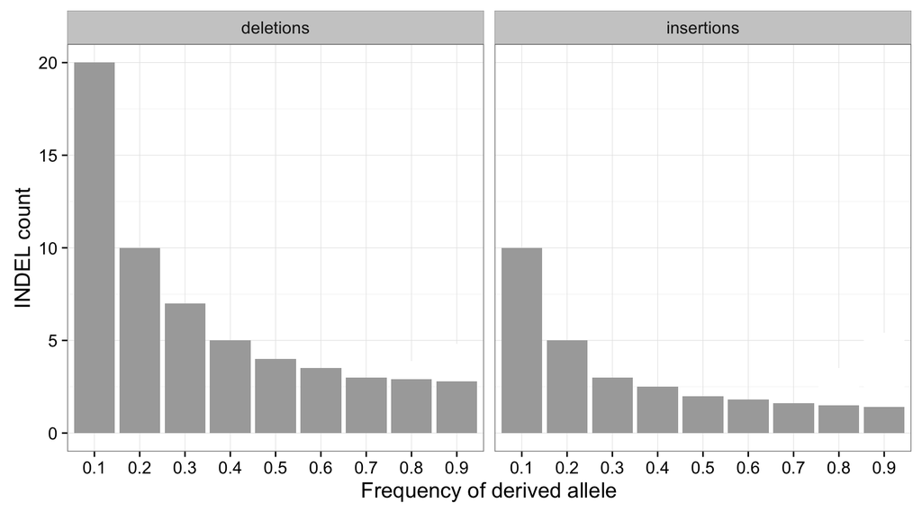

(see Hernandez et al., 2007)

## Importance of polarisation error

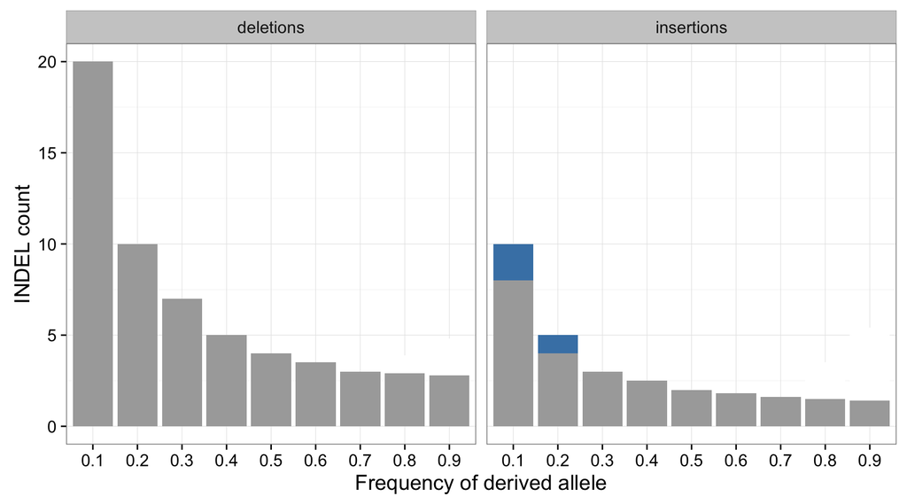

(see Hernandez et al., 2007)

## Importance of polarisation error

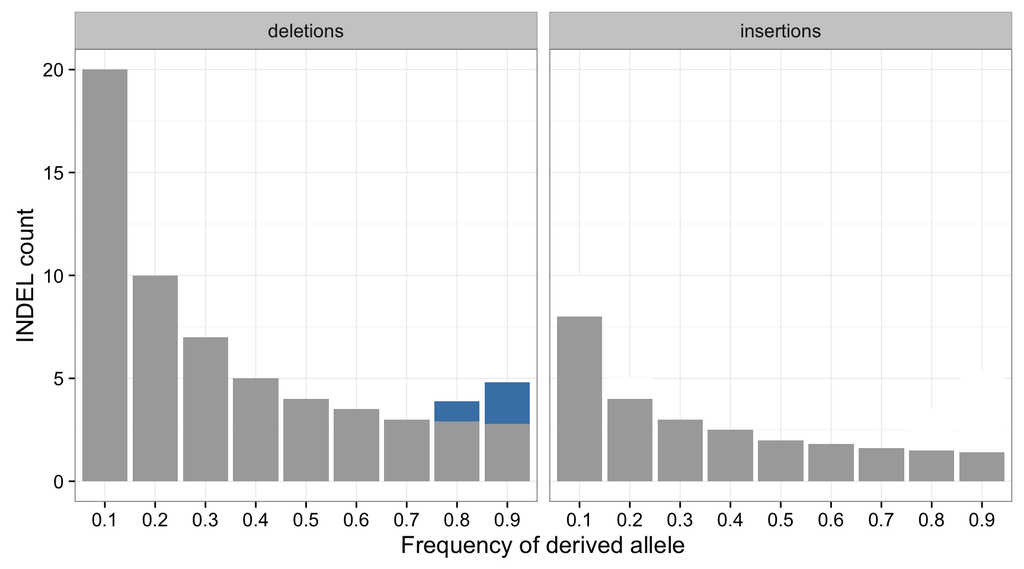

(see Hernandez et al., 2007)

## Importance of polarisation error

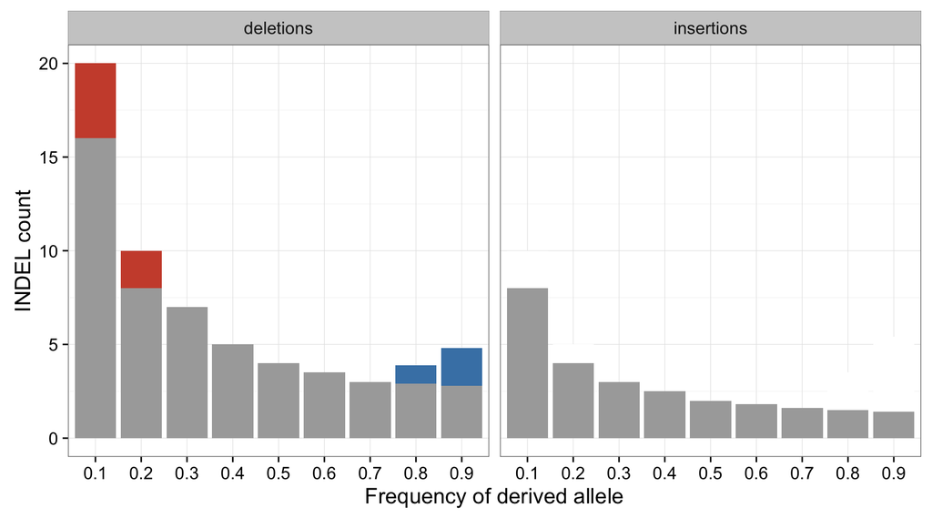

(see Hernandez et al., 2007)

## Importance of polarisation error

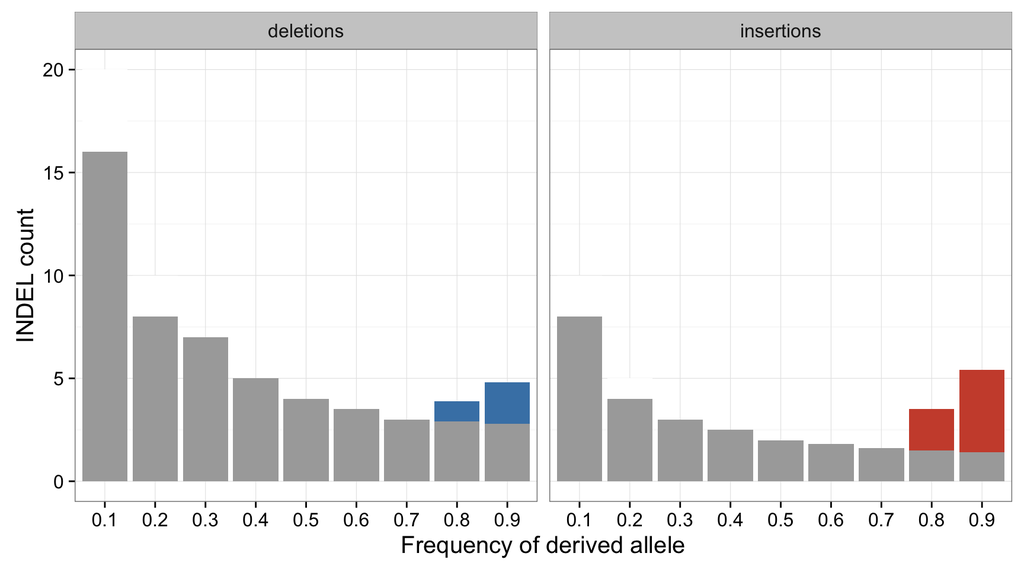

(see Hernandez et al., 2007)

## Importance of polarisation error

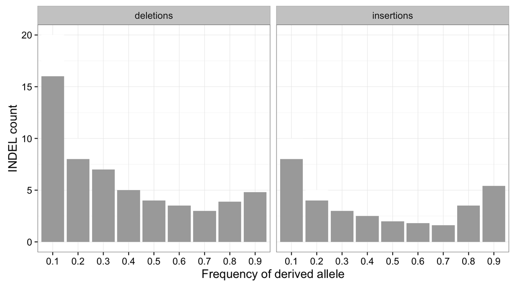

(see Hernandez et al., 2007)

## Aims

1. Overcome polarisation error using a novel modelling approach
2. Quanitfy the selective and mutational pressures acting on INDELs in great tits (*Parus major*)
3. Investigate how these pressures vary in different genomic contexts, ie chromosome length

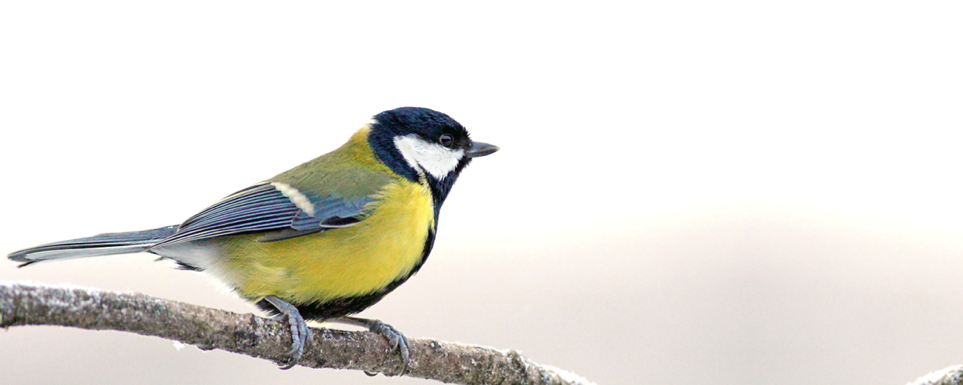

## Advantages of an avian system

- Highly dynamic recombination landscape
- Genomes consist of few large macrochromosomes and many small microchromosomes

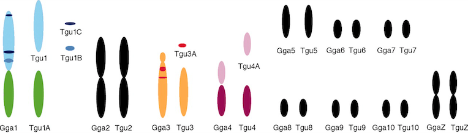

(van Oers et al., 2014; Stapley et al., 2008)

## Approach - data

## Sample and pipeline

- 10 european great tit males
- high coverage (44x)
- variant calling with GATK
- multispecies alignment between zebra finch, flycatcher and great tit
- parsimony based polarisation

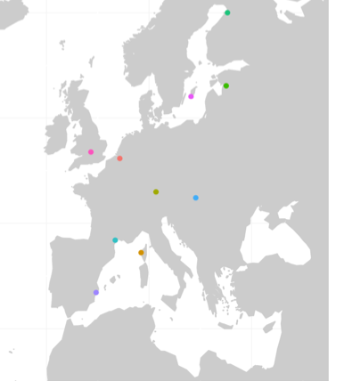

## Approach - model

## Glémin model

- Adapting Glémin et al. (2015) model to INDELs
- Takes unfolded site frequency spectrum for insertions, deletions and neutral SNPs
- Estimates \(\theta\), \(\gamma\) and \(\kappa\)
- Estimates and accounts for polarisation error

**\(\theta = 4N_e\mu\)**

**\(\gamma = 4N_es\)**

**\(\kappa = \mu_d / \mu_i\)**

## Predicts \(\theta\) well

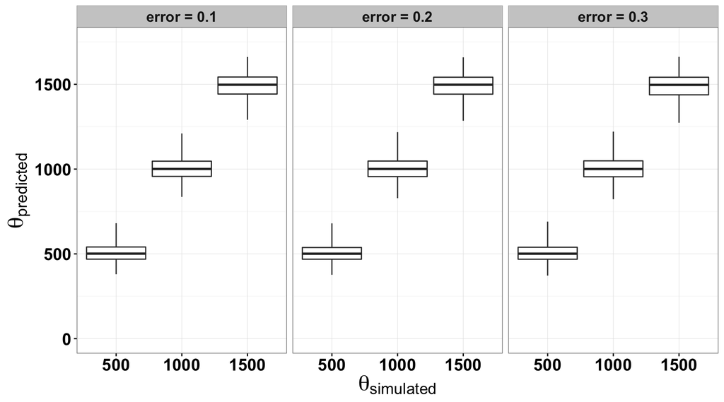

## Predicts \(\gamma\) well

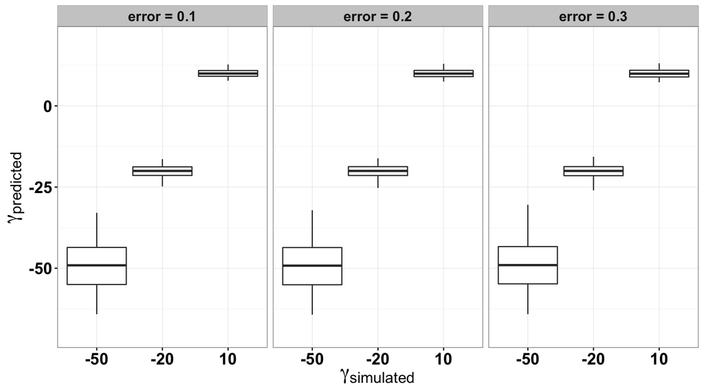

## Predicts \(\kappa\) well

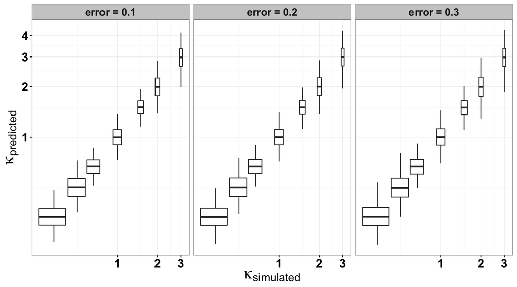

## Regional Results

## Regional variation in purifying selection

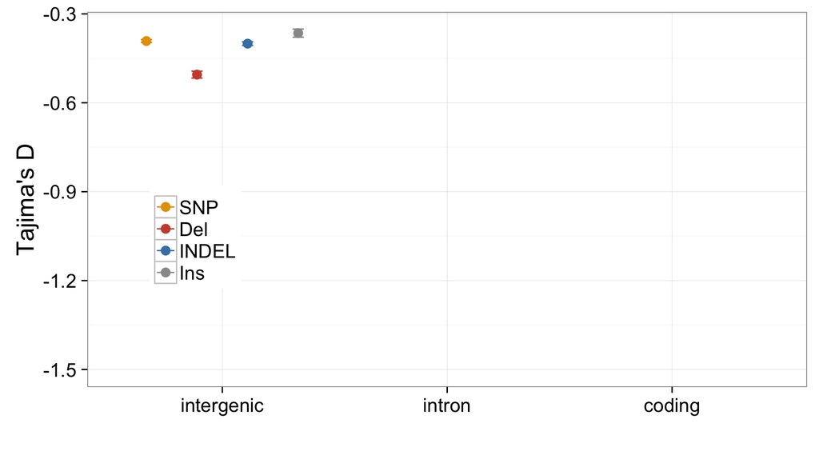

## Regional variation in purifying selection

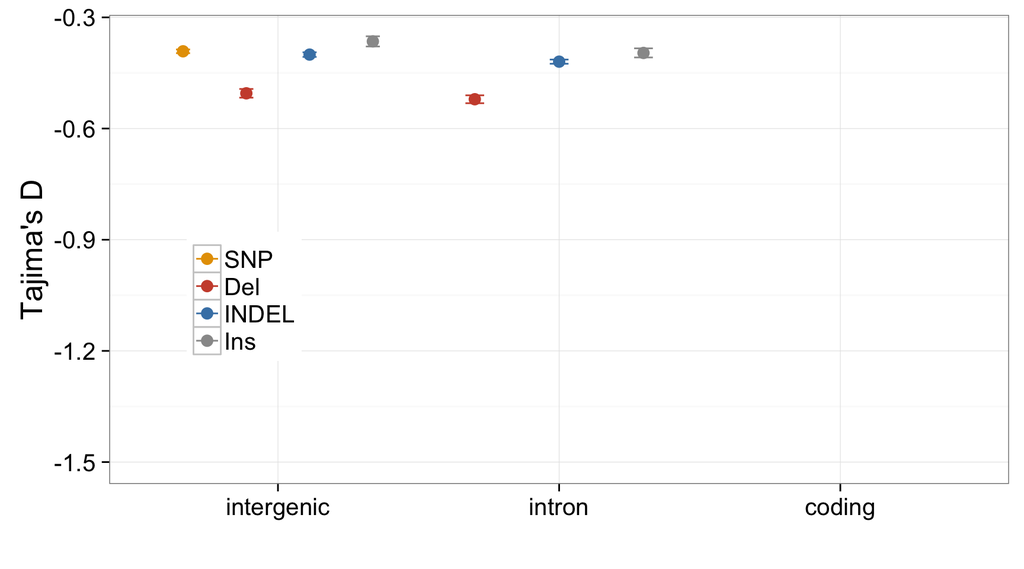

## Regional variation in purifying selection

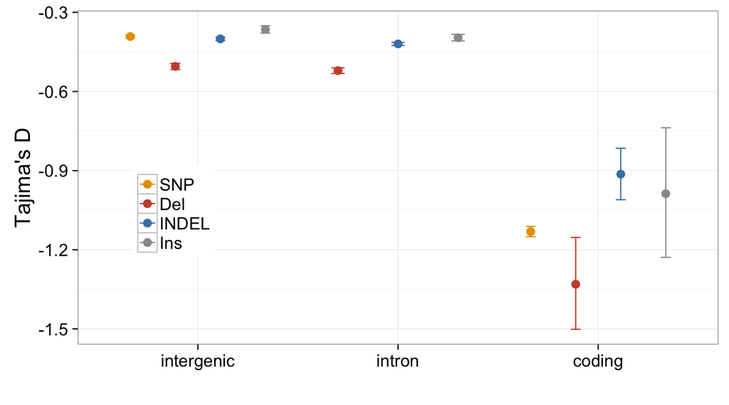

## INDELs deleterious in coding regions

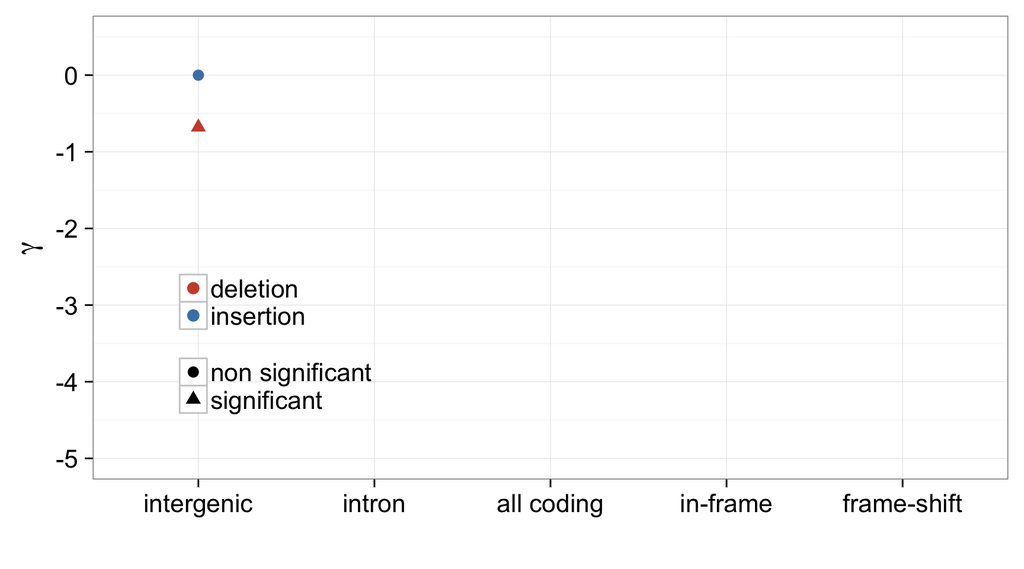

## INDELs deleterious in coding regions

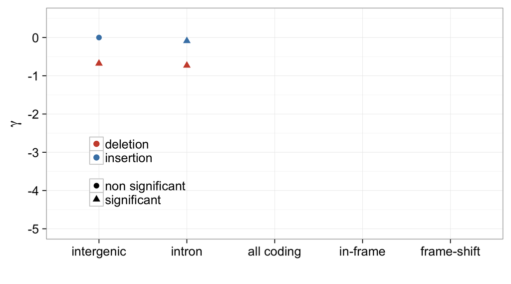

## INDELs deleterious in coding regions

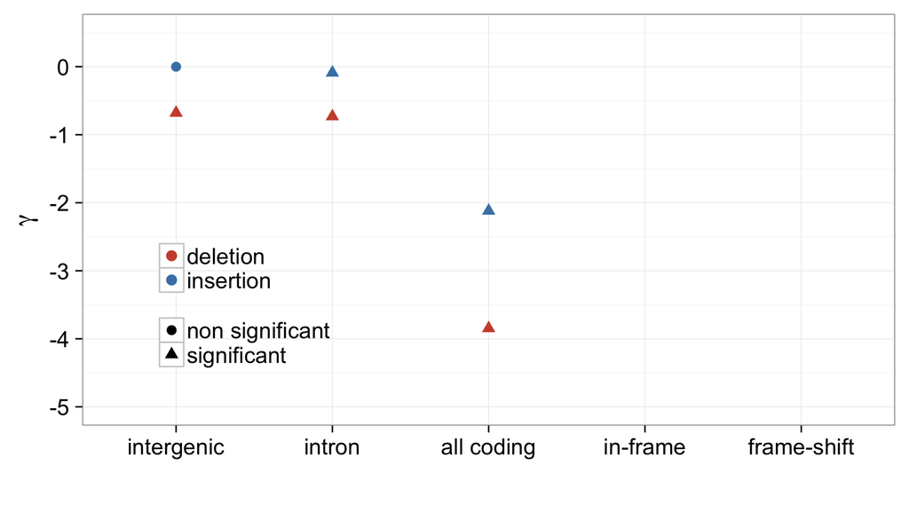

## INDELs deleterious in coding regions

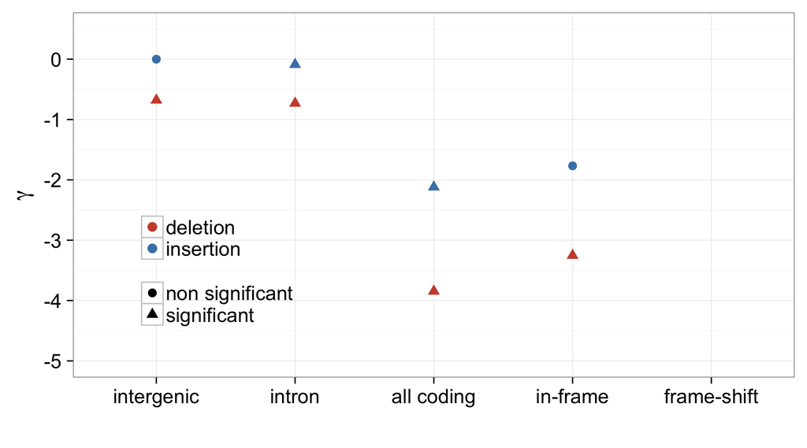

## INDELs deleterious in coding regions

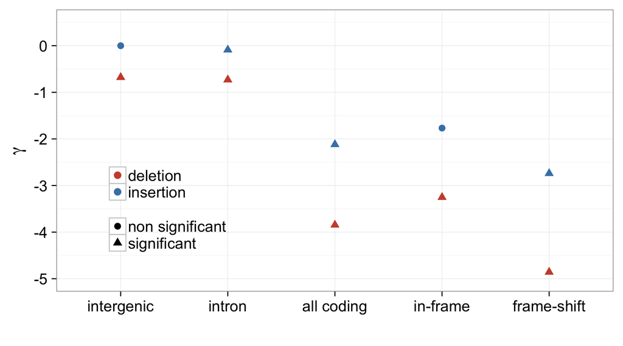

## Recombination Results

## No relationship between \(\gamma\) and chromosome

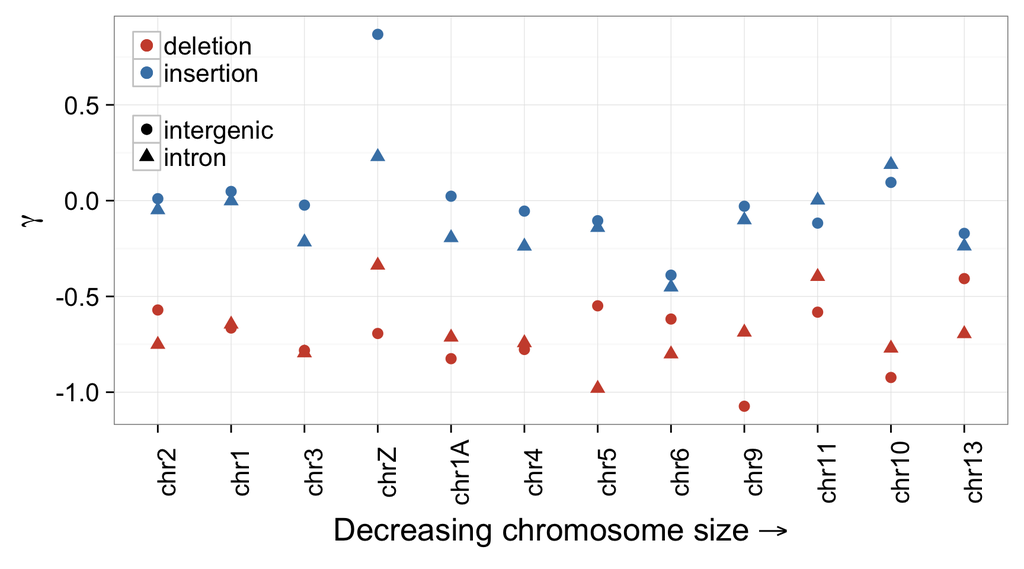

## No relationship between \(\kappa\) (deletion bias) and chromosome length

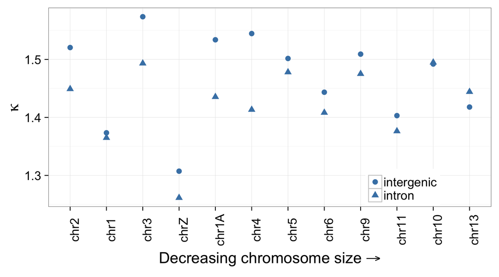

## Conclusions

- INDELs in intergenic and intronic regions largely neutral
- Coding INDELs strongly deleterious
- No evidence for increasing deletion rate with decreasing chromosome size

## Acknowledgements

- Kai Zeng
- Pádraic Corcoran
- Toni Gossmann